# Date - Time

```r
if(!file.exists("./data/data.csv")){source(getData.R)}
ext_tracks <- read.csv("./data/data.csv")
```

## Converting to a date or date-time class

The lubridate package (another package from the “tidyverse”) has some excellent functions for working with dates in R. First, this package includes functions to transform objects into date or date-time classes. For example, the ymd_hm function (along with other functions in the same family: ymd, ymd_h, and ymd_hms) can be used to convert a vector from character class to R’s data and datetime classes, POSIXlt and POSIXct, respectively. Functions in this family can be used to parse character strings into dates, regardless of how the date is formatted, as long as the date is in the order: year, month, day (and, for time values, hour, minute). For example:

```r
library(lubridate)

ymd("2006-03-12")
```

```
## [1] "2006-03-12"
```

```r
ymd("'06 March 12")
```

```
## [1] "2006-03-12"
```

```r
ymd_hm("06/3/12 6:30 pm")
```

```
## [1] "2006-03-12 18:30:00 UTC"
```

The following code shows how to use the ymd_h function to transform the date and time information in a subset of the hurricane example data called andrew_tracks (the storm tracks for Hurricane Andrew) to a date-time class (POSIXct). This code also uses the *unite function from the tidyr package* to join together date components that were originally in separate columns before applying ymd_h.

```r
library(dplyr)
library(tidyr)
andrew_tracks <- ext_tracks %>%
  filter(storm_name == "ANDREW" & year == "1992") %>%
  select(year, month, day, hour, max_wind, min_pressure) %>%
  unite(datetime, year, month, day, hour) %>%
  mutate(datetime = ymd_h(datetime))

head(andrew_tracks, 5)
```

```
##              datetime max_wind min_pressure
## 1 1992-08-16 18:00:00       25         1010
## 2 1992-08-17 00:00:00       30         1009
## 3 1992-08-17 06:00:00       30         1008
## 4 1992-08-17 12:00:00       35         1006
## 5 1992-08-17 18:00:00       35         1003
```

```r
class(andrew_tracks$datetime)
```

```
## [1] "POSIXct" "POSIXt"
```

Now that the datetime variable in this dataset has been converted to a date-time class, the variable becomes much more useful. For example, if you plot a time series using datetime, ggplot2 can recognize that this object is a date-time and will make sensible axis labels. The following code plots maximum wind speed and minimum air pressure at different observation times for Hurricane Andrew (Figure 1.3) – check the axis labels to see how they’ve been formatted. Note that this code uses gather from the tidyr package to enable easy faceting to create separate plots for wind speed and air pressure.

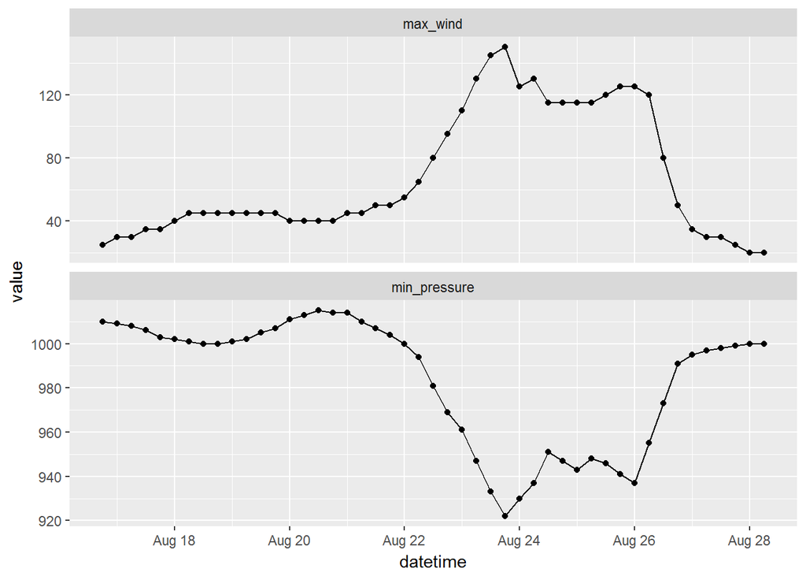

```r
library(ggplot2)
andrew_tracks %>%
  gather(measure, value, -datetime) %>%
  ggplot(aes(x = datetime, y = value)) +
  geom_point() + geom_line() +
  facet_wrap(~ measure, ncol = 1, scales = "free_y")
```

Figure 1.3: Example of how variables in a date-time class can be parsed for sensible axis labels.

Note:

```r
args(facet_grid)
```

```
## function (facets, margins = FALSE, scales = "fixed", space = "fixed",
##     shrink = TRUE, labeller = "label_value", as.table = TRUE,
##     switch = NULL, drop = TRUE)
## NULL
```

Are scales shared across all facets (the default, “fixed”), or do they vary across rows (“free_x”), columns (“free_y”), or both rows and columns (“free”)

## Pulling out date/time elements

Once an object is in a date or date-time class (POSIXlt orPOSIXct, respectively), there are other functions in the lubridate package you can use to pull certain elements out of it. For example, you can use the functions year, months,mday, wday, yday, weekdays, hour, minute, and second to pull the year, month, month day, etc., of the date. The following code uses the datetime variable in the Hurricane Andrew track data to add new columns for the year, month, weekday, year day, and hour of each observation:

```r
andrew_tracks %>%
  select(datetime) %>%
  mutate(year = year(datetime),
         month = months(datetime),
         weekday = weekdays(datetime),
         yday = yday(datetime),
         hour = hour(datetime)) %>%
  slice(1:3)
```

```
##              datetime year  month weekday yday hour
## 1 1992-08-16 18:00:00 1992 August  Sunday  229   18
## 2 1992-08-17 00:00:00 1992 August  Monday  230    0
## 3 1992-08-17 06:00:00 1992 August  Monday  230    6
```

This functionality makes it easy to look at patterns in the max_wind value by different time groupings, like weekday and month. For example, the following code puts together some of the dplyr and tidyr data cleaning tools and ggplot2 plotting functions with these lubridate functions to look at the average value of max_wind storm observations by day of the week and by month (Figure 1.4).

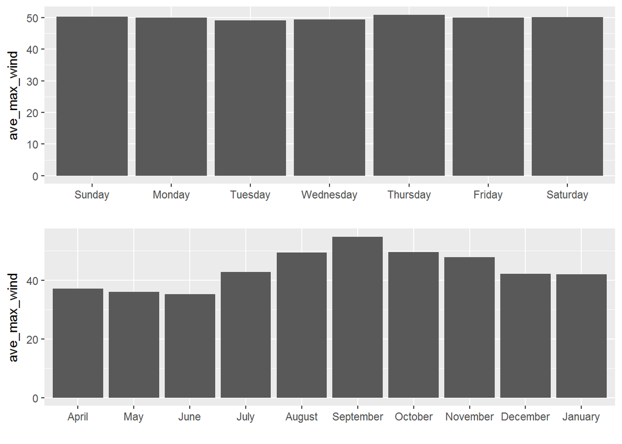

```r
check_tracks <- ext_tracks %>%
  select(month, day, hour, year, max_wind) %>%
  unite(datetime, year, month, day, hour) %>%
  mutate(datetime = ymd_h(datetime),
         weekday = weekdays(datetime),
         weekday = factor(weekday, levels = c("Sunday", "Monday",
                                              "Tuesday", "Wednesday",
                                              "Thursday", "Friday",
                                              "Saturday")),
         month = months(datetime),
         month = factor(month, levels = c("April", "May", "June",
                                          "July", "August", "September",
                                          "October", "November",
                                          "December", "January")))

check_weekdays <- check_tracks %>%
  group_by(weekday) %>%
  summarize(ave_max_wind = mean(max_wind)) %>%
  rename(grouping = weekday)
check_months <- check_tracks %>%
  group_by(month) %>%
  summarize(ave_max_wind = mean(max_wind)) %>%
  rename(grouping = month)

a <- ggplot(check_weekdays, aes(x = grouping, y = ave_max_wind)) +
  geom_bar(stat = "identity") + xlab("")
b <- a %+% check_months

library(gridExtra)
grid.arrange(a, b, ncol = 1)
```

Figure 1.4: Example of using lubridate functions to explore data with a date variable by different time groupings

Based on Figure 1.4, there’s little pattern in storm intensity by day of the week, but there is a pattern by month, with the highest average wind speed measurements in observations in September and neighboring months (and no storm observations in February or March).

There are a few other interesting things to note about this code:

- To get the weekday and month values in the right order, the code uses the factor function in conjunction with the levels option, to control the order in which R sets the factor levels. By specifying the order we want to use with levels, the plot prints out using this order, rather than alphabetical order (try the code without the factor calls for month and weekday and compare the resulting graphs to the ones shown here).
- The grid.arrange function, from the gridExtra package, allows you to arrange different ggplot objects in the same plot area. Here, I’ve used it to put the bar charts for weekday (a) and for month (b) together in one column (ncol = 1).
- If you ever have ggplot code that you would like to re-use for a new plot with a different data frame, you can save a lot of copying and pasting by using the *%+% function*. This function takes a ggplot object (a in this case, which is the bar chart by weekday) and substitutes a different data frame (check_months) for the original one (check_weekdays), but otherwise maintains all code. Note that we used rename to give the x-variable the same name in both datasets so we could take advantage of the %+% function.